# Biterm Modeling of Performance Scales

## About BTM

Biterm Topic Modeling (BTM) is a method of detecting the topics occurring in short texts. In other approaches to topic modeling, each document is analyzed for topic occurences within that document. The challenge with applying traditional topic modeling techniques to short documents is that there is not enough data to work with. BTM solves this problem by analyzing the entire corpus of documents together.

BTM works by colleting information about biterms in the document corpus. A "biterm" is an unordered co-occurence of words.

Our data consists of individual items taken from performance evaluation scales. Since each item is the length of a sentence, we decided it would be appropriate to apply BTM to our data. We hope to uncover common topics in performance scales using BTM techniques.

## Methods

Here the model is defined. We kept the alpha and beta parameters standard to maintain a balance in the output between the number, specificity, and type of the topics. K was set to 10 to indicate that 10 topics should be identified.

```
## Biterm Topic Model
##   trained with 1000 Gibbs iterations, alpha: 5, beta: 0.1
##   topics: 10
##   size of the token vocabulary: 2118
##   topic distribution theta: 0.076 0.065 0.13 0.097 0.106 0.08 0.109 0.096 0.089 0.152
```

Biterms used in the model are displayed.

|  | term1 | term2 | topic |
| --- | --- | --- | --- |
| 1 | coworkers | told | 3 |
| 2 | accepting | coworkers | 10 |
| 3 | coworkers | people | 10 |
| 4 | accepting | told | 10 |
| 5 | people | told | 10 |
| 6 | accepting | people | 10 |
| 7 | coworkers | told | 10 |
| 8 | coworkers | feel | 10 |
| 9 | coworkers | respect | 3 |
| 10 | coworkers | opinions | 10 |

[output cut: 13883 more lines]

## Output

These themes can help us begin to understand the components of performance. Understanding the essence of performance is an important step in improving performance, which could increase both productivity and satisfaction.

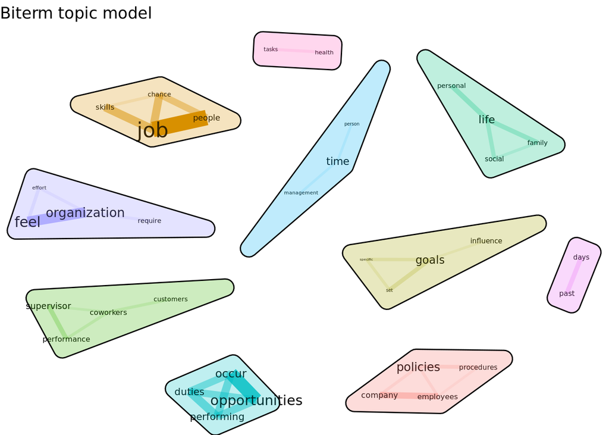